# Theory of Happiness

Hector Santana

December 8, 2017

### Hypothesis: Modern day happiness often seems to be based on the theory that money is the primary derivative for all purpose, comfort, pleasure, etc. The belief is that money is essentially the root to happiness. By examining the below data on a high level, we can determine how true that is, especially with respect to the USA. Happiness/satisfaction will then be measured on a career basis for the USA alone using similar methods. The primary goal in this analysis is thus to disprove the notion that wealth is the primary contributor to universal happiness.

### Cleaning and prepping the data

### Load Libraries

```r
suppressMessages(suppressWarnings(library(tidyr)))
suppressMessages(suppressWarnings(library(dplyr)))
suppressMessages(suppressWarnings(library(ggplot2)))
suppressMessages(suppressWarnings(library(RCurl)))
suppressMessages(suppressWarnings(library(ggrepel)))
suppressMessages(suppressWarnings(library(XML)))
suppressMessages(suppressWarnings(library(rvest)))
```

```r
twenty_fifteen_happiness = read.csv(text = getURL('https://raw.githubusercontent.com/manonfire86/FinalProject/master/2015_Happiness.csv'))
twenty_sixteen_happiness = read.csv(text = getURL('https://raw.githubusercontent.com/manonfire86/FinalProject/master/2016_Happiness.csv'))
twenty_seventeen_happiness = read.csv(text = getURL('https://raw.githubusercontent.com/manonfire86/FinalProject/master/2017_Happiness.csv'))

globalOECDGDP = read.csv(text = getURL('https://raw.githubusercontent.com/manonfire86/FinalProject/master/API_NY.GDP.PCAP.CD_DS2_en_excel_v2.csv'))

avgworldincome = 'https://www.worlddata.info/average-income.php'
avgworldincometable  = avgworldincome %>%
  read_html() %>%
  html_nodes(xpath='//*[@id="tabsort"]') %>%
  html_table(fill=TRUE)

careersatisfaction = read.csv(text = getURL('https://raw.githubusercontent.com/manonfire86/FinalProject/master/career_satisfaction_14_11_2017.csv'))
```

### Global Happiness Reports: 2015-2017 (cleaning and prepping the data)

```r
twenty_fifteen_happiness_sub = twenty_fifteen_happiness[,c('Country','Happiness.Rank')]
twenty_fifteen_happiness_sub['Year'] = 2015

twenty_sixteen_happiness_sub = twenty_sixteen_happiness[,c('Country','Happiness.Rank')]
twenty_sixteen_happiness_sub['Year'] = 2016

twenty_seventeen_happiness_sub = twenty_seventeen_happiness[,c('Country','Happiness.Rank')]
twenty_seventeen_happiness_sub['Year'] = 2017

longformat_twenty_fifteen_happiness = twenty_fifteen_happiness_sub %>%
  spread(Year,Happiness.Rank)

longformat_twenty_sixteen_happiness = twenty_sixteen_happiness_sub %>%
  spread(Year,Happiness.Rank)

longformat_twenty_seventeen_happiness = twenty_seventeen_happiness_sub %>%
  spread(Year,Happiness.Rank)


happiness_ranking_df = merge(longformat_twenty_fifteen_happiness,longformat_twenty_sixteen_happiness,by= 'Country')
happiness_ranking_df = merge(happiness_ranking_df,longformat_twenty_seventeen_happiness,'Country')

happiness_ranking_df = happiness_ranking_df %>%
  gather(Year, Rank,'2015':'2017')

top30countries = subset(happiness_ranking_df,Rank<=30)
```

### Mapping the top 30 countries in terms of Happiness Ranking and determining the top absolute changes year over year

```r
countriessorted = happiness_ranking_df[with(happiness_ranking_df,order(Country,Year,Rank)),]
countriesyoy = countriessorted %>% mutate( chg = ifelse(Country == lag(Country),Rank - lag(Rank),0))
countriesyoy['Abs_Change'] = abs(countriesyoy['chg'])
avgyoychange = countriesyoy[,c('Country','Year','Abs_Change')] %>%
  spread(Year,Abs_Change)


avgyoychange[is.na(avgyoychange)] = 0

avgyoychange["Average Change Across Yrs"] = rowMeans(avgyoychange[,2:4])

toptenchanges = avgyoychange[order(avgyoychange$`Average Change Across Yrs`,decreasing = T),]
toptenchanges = head(toptenchanges,10)

purechanges = countriesyoy[which(countriesyoy$Country %in% toptenchanges$Country),]
purechanges = purechanges[,c('Country','Year','chg')] %>%
  spread(Year,chg)
purechanges["Average Change Across Yrs"] = rowMeans(purechanges[,2:4])
purechanges = purechanges[order(purechanges$`Average Change Across Yrs`),]
```

### What was the contributing factor based on the Happiness Index Data for the countries with the top 10 largest changes

```r
twenty_fifteen_happiness_attr = twenty_fifteen_happiness[,-2:-5]
twenty_sixteen_happiness_attr = twenty_sixteen_happiness[,-2:-6]
twenty_seventeen_happiness_attr = twenty_seventeen_happiness[,-2:-5]

twenty_fifteen_attr_changes = twenty_fifteen_happiness_attr[which(twenty_fifteen_happiness_attr$Country %in% toptenchanges$Country),]
twenty_sixteen_attr_changes = twenty_sixteen_happiness_attr[which(twenty_sixteen_happiness_attr$Country %in% toptenchanges$Country),]
twenty_seventeen_attr_changes = twenty_seventeen_happiness_attr[which(twenty_seventeen_happiness_attr$Country %in% toptenchanges$Country),]

twenty_fifteen_attr_changes['Year'] = 2015
twenty_sixteen_attr_changes['Year'] = 2016
twenty_seventeen_attr_changes['Year'] = 2017

twenty_fifteen_attr_changes=twenty_fifteen_attr_changes[,-8]
twenty_sixteen_attr_changes = twenty_sixteen_attr_changes[,-8]
twenty_seventeen_attr_changes = twenty_seventeen_attr_changes[,-8]


newnamevector = c('Country','Economy','Family','Health','Freedom','Trust in Government','Generosity','Year')

colnames(twenty_fifteen_attr_changes) = newnamevector
colnames(twenty_sixteen_attr_changes) = newnamevector
colnames(twenty_seventeen_attr_changes) = newnamevector

longdffifteen = twenty_fifteen_attr_changes %>%
  gather(Attribute,Factor,Economy:Generosity) %>%
  spread(Year,Factor)

longdfsixteen = twenty_sixteen_attr_changes %>%
  gather(Attribute,Factor,Economy:Generosity) %>%
  spread(Year,Factor)

longdfseventeen = twenty_seventeen_attr_changes %>%
  gather(Attribute,Factor,Economy:Generosity) %>%
  spread(Year,Factor)

merged_attr_df = merge(longdffifteen,longdfsixteen,by=c('Country','Attribute'))
merged_attr_df = merge(merged_attr_df,longdfseventeen,by=c('Country','Attribute'))
merged_attr_df = merged_attr_df %>%
  gather(Year,Factor,'2015':'2017')

attributessorted = merged_attr_df[with(merged_attr_df,order(Country,Attribute,Year)),]
attributesyoy = attributessorted %>% mutate( chg = ifelse(Country == lag(Country) & Attribute == lag(Attribute),Factor - lag(Factor),0))
avgyoyattrchange = attributesyoy[,c('Country','Attribute','Year','chg')] %>%
  spread(Year,chg)

avgyoyattrchange[is.na(avgyoyattrchange)] = 0
avgyoyattrchange["Average Change Across Yrs"] = rowMeans(avgyoyattrchange[,3:5])

LargestContributingAttr = avgyoyattrchange[,c('Country','Attribute','Average Change Across Yrs')] %>%
  spread(Attribute,'Average Change Across Yrs')

maxattributeeachcountry = avgyoyattrchange[,c('Country','Attribute','Average Change Across Yrs')] %>% group_by(Country) %>% top_n(1,abs(`Average Change Across Yrs`))
```

### Examining the USA: Career Satisfaction and Global Income Standing

```r
twenty_fifteen_happiness_USA = twenty_fifteen_happiness[,-2:-5]
twenty_sixteen_happiness_USA = twenty_sixteen_happiness[,-2:-6]
twenty_seventeen_happiness_USA = twenty_seventeen_happiness[,-2:-5]

twenty_fifteen_happiness_USA['Year'] = 2015
twenty_sixteen_happiness_USA['Year'] = 2016
twenty_seventeen_happiness_USA['Year'] = 2017

twenty_fifteen_happiness_USA=twenty_fifteen_happiness_USA[,-8]
twenty_sixteen_happiness_USA = twenty_sixteen_happiness_USA[,-8]
twenty_seventeen_happiness_USA = twenty_seventeen_happiness_USA[,-8]

colnames(twenty_fifteen_happiness_USA) = newnamevector
colnames(twenty_sixteen_happiness_USA) = newnamevector
colnames(twenty_seventeen_happiness_USA) = newnamevector


USAdffifteen = twenty_fifteen_happiness_USA %>%
  gather(Attribute,Factor,Economy:Generosity) %>%
  spread(Year,Factor)

USAdfsixteen = twenty_sixteen_happiness_USA %>%
  gather(Attribute,Factor,Economy:Generosity) %>%
  spread(Year,Factor)

USAdfseventeen = twenty_seventeen_happiness_USA %>%
  gather(Attribute,Factor,Economy:Generosity) %>%
  spread(Year,Factor)

merged_attr_USA = merge(USAdffifteen,USAdfsixteen,by=c('Country','Attribute'))
merged_attr_USA = merge(merged_attr_USA,USAdfseventeen,by=c('Country','Attribute'))
merged_attr_USA = merged_attr_USA %>%
  gather(Year,Factor,'2015':'2017')

attributesUSA = merged_attr_USA[which(merged_attr_USA$Country == "United States"),]
attributesUSA= attributesUSA[with(attributesUSA,order(Country,Attribute,Year)),]
attributesUSAyoy = attributesUSA %>% mutate( chg = ifelse(Country == lag(Country) & Attribute == lag(Attribute),Factor - lag(Factor),0))
avgyoyUSAchange = attributesUSAyoy[,c('Country','Attribute','Year','chg')] %>%
  spread(Year,chg)

avgyoyUSAchange[is.na(avgyoyUSAchange)] = 0
avgyoyUSAchange["Average Change Across Yrs"] = rowMeans(avgyoyUSAchange[,3:5])
```

### Career Satisfaction

```r
careersatisfactionUSA = careersatisfaction

factoraverages = colMeans(careersatisfactionUSA[6:12])
salary_average = mean(careersatisfaction[is.na(careersatisfactionUSA$Salary....USD.)==FALSE,"Salary....USD."])

salarymapping = careersatisfaction[is.na(careersatisfactionUSA$Salary....USD.)==FALSE,]
salarymapping = salarymapping[order(-salarymapping[,4]),]

careersatisfactionUSA[is.na(careersatisfactionUSA)]=0


heatmaptable = salarymapping[,-2:-6]

heatmaptable = heatmaptable[1:50,] %>%
  gather(Attribute,Factor, Fit:Salary)

analysistableheat = salarymapping[,c(-2,-3,-5)]
analysistableheat = analysistableheat[1:50,]
```

### Average Global Income

```r
avgworldincomedf = avgworldincometable[[1]]
colnames(avgworldincomedf) = avgworldincomedf[1,]
avgworldincomedf = avgworldincomedf[-1,-5]
row.names(avgworldincomedf) = avgworldincomedf[,1]
avgworldincomedf[] = lapply(avgworldincomedf,gsub,pattern = ',',replacement = '')
avgworldincomedf[] = lapply(avgworldincomedf,gsub,pattern = '\\$',replacement = '')
avgworldincomedf$`Average incomeannually` = as.numeric(avgworldincomedf$`Average incomeannually`)
avgworldincomedf$monthly = as.numeric(avgworldincomedf$monthly)

USAglobalincomerank = avgworldincomedf[which(avgworldincomedf$Country == 'United States'),]
```

### Global OECD GDP Data

```r
globalOECDGDP[is.na(globalOECDGDP)] = 0

globalOECDGDPparsedfourteen = globalOECDGDP[,c("Country.Name","X2014")]
globalOECDGDPparsedfifteen = globalOECDGDP[,c("Country.Name","X2015")]
globalOECDGDPparsedsixteen = globalOECDGDP[,c("Country.Name","X2016")]


globalOECDGDPparsedfourteen = globalOECDGDPparsedfourteen[with(globalOECDGDPparsedfourteen,order(-globalOECDGDPparsedfourteen$X2014)),]
globalOECDGDPparsedfifteen = globalOECDGDPparsedfifteen[with(globalOECDGDPparsedfifteen,order(-globalOECDGDPparsedfifteen$X2015)),]
globalOECDGDPparsedsixteen = globalOECDGDPparsedsixteen[with(globalOECDGDPparsedsixteen,order(-globalOECDGDPparsedsixteen$X2016)),]

toptentableoecd = merge(globalOECDGDPparsedfourteen,globalOECDGDPparsedfifteen,by = 'Country.Name')
toptentableoecd = merge(toptentableoecd,globalOECDGDPparsedsixteen,by = 'Country.Name')
toptentableoecd = toptentableoecd[with(toptentableoecd,order(-X2016,-X2015,-X2014)),]
toptentableoecdfinal = toptentableoecd[1:10,]

tennamescols = c('Countries','2014','2015','2016')

colnames(toptentableoecdfinal) = tennamescols

toptentableoecdfinal = toptentableoecdfinal %>%
  gather(Year,Average_GDP,`2014`:`2016`)
```

### Below is the mapping of the top 30 Countries Based on Happiness Rankings from 2015 to 2017. As you can see there are some major shifts where countries lost there entire standing within the top 30 or gained position within the top 30, for instance the Czech Republic was not present in 2015, but it made the top 30 in 2016 and 2017. The USA shifted between rank 15, 13, and 14 between 2015 and 2017.

### Analysis: Top 30 Ranked Countries from 2015-2017

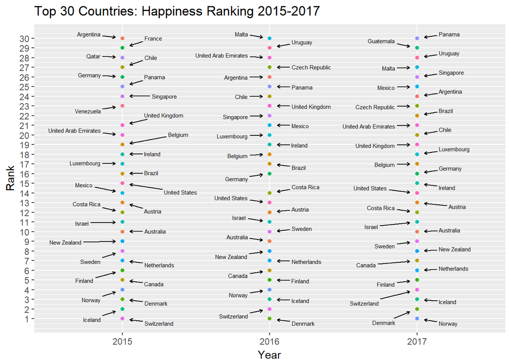

### Given the macro level, it is safe to question what were the largest contributing factors for countries that experience the largest shifts in rankings. Taking the absolute average changes in the data set and then mapping these rankings to their natural year over year changes, I parsed the top 10 countries that experienced the greatest shifts.

### I then included the data set’s happiness factors and mapped them accordingly. This is the first confirmation that money is not the root of happiness; economic sentiment did not have the greatest impact for 70% of the countries mapped. In fact, it was often the compounding effect of all attributes affected in that year that caused the shift in rankings.

### Ten countries with largest Rank shifts: Contributing Factors

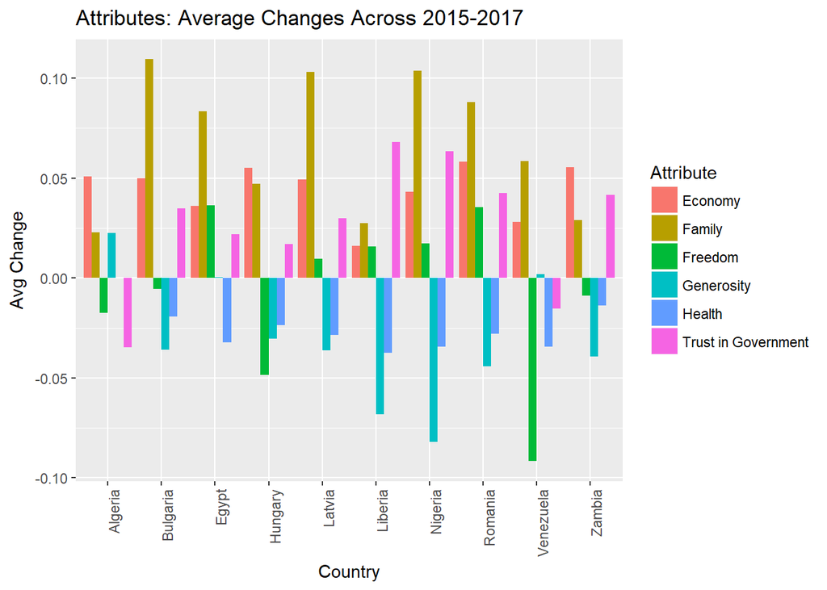

### Attributes: Greatest Average Changes Across 2015-2017 for the Ten Selected Countries

```r
print(maxattributeeachcountry)
```

```
## # A tibble: 10 x 3
## # Groups:   Country [10]
##      Country  Attribute `Average Change Across Yrs`
##       <fctr>      <chr>                       <dbl>
##  1   Algeria    Economy                  0.05085816
##  2  Bulgaria     Family                  0.10941315
##  3     Egypt     Family                  0.08349046
##  4   Hungary    Economy                  0.05502398
##  5    Latvia     Family                  0.10303165
##  6   Liberia Generosity                 -0.06822392
##  7   Nigeria     Family                  0.10381683
##  8   Romania     Family                  0.08807043
##  9 Venezuela    Freedom                 -0.09169429
## 10    Zambia    Economy                  0.05534226
```

### Examining the USA specifically, changes in economic sentiment did not have the greatest impact in the rank shifts experienced between 2015 and 2017. The largest affected factor was a sharp decline in geneorsity over the years while trust in government experienced the highest positive average change.

### USA: Contributing Factors

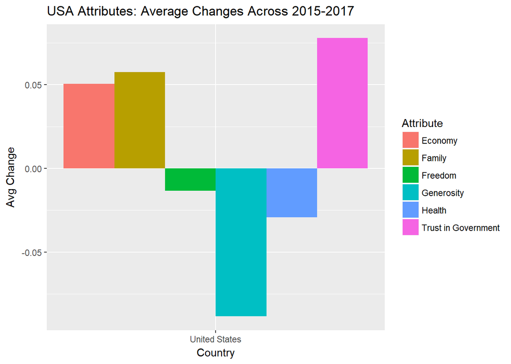

### USA: Average Changes 2015-2017

```r
print(avgyoyUSAchange)
```

```
##         Country           Attribute 2015     2016         2017
## 1 United States             Economy    0  0.11345  0.038299284
## 2 United States              Family    0 -0.19929  0.372100564
## 3 United States             Freedom    0 -0.06441  0.024110523
## 4 United States          Generosity    0  0.00972 -0.275131212
## 5 United States              Health    0 -0.08279 -0.004713372
## 6 United States Trust in Government    0 -0.01022  0.243898781
##   Average Change Across Yrs
## 1                0.05058309
## 2                0.05760352
## 3               -0.01343316
## 4               -0.08847040
## 5               -0.02916779
## 6                0.07789293
```

### Heat Map of Job Happiness USA

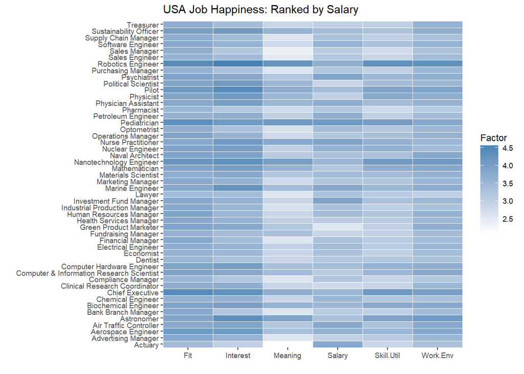

### Overall Scores: Career Satisfaction for the Top 50 paying jobs

```r
print(analysistableheat)
```

```
##                                          Name Salary....USD. Overall Fit
## 218                              Psychiatrist         181880     3.4 3.9
## 116                           Chief Executive         173320     3.9 4.4
## 370                    Sustainability Officer         173320     3.6 4.0
## 209                              Pediatrician         163350     4.0 4.3
## 7                                     Dentist         149540     3.0 3.5
## 471                        Petroleum Engineer         130050     3.0 3.6
## 387                         Marketing Manager         127130     3.2 3.8
## 96                     Air Traffic Controller         122340     3.3 3.8
## 49                                 Pharmacist         120950     2.8 3.5
## 338             Clinical Research Coordinator         120050     2.9 3.7
## 92                                      Pilot         118140     3.9 4.1
## 321                         Financial Manager         115320     3.0 3.8
## 334                       Bank Branch Manager         115320     2.8 3.8
## 364                                 Treasurer         115320     3.1 3.7
```

[output cut: 87 more lines]

### Average Annual Global Income: Top 50 countries

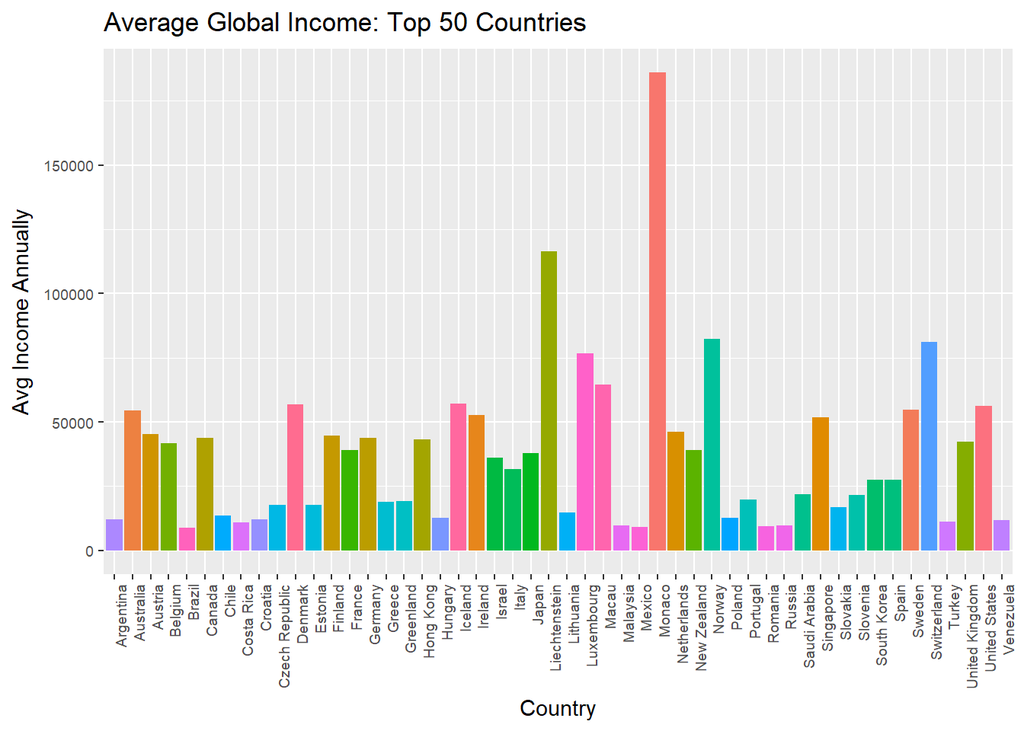

### OECD GDP Mapping

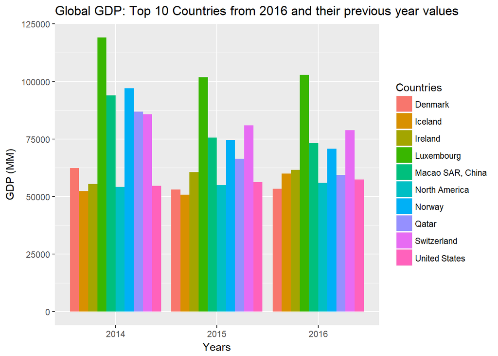

### Directionally Correct Salary Comparison

```r
Differenceinincomesources = USAglobalincomerank$`Average incomeannually` - salary_average
print(paste("There is only a",abs(round(Differenceinincomesources,0)),"dollar difference in the average salaries calculated in the Average Annual World Income Data and Career Satisfication data for the USA"))
```

```
## [1] "There is only a 584 dollar difference in the average salaries calculated in the Average Annual World Income Data and Career Satisfication data for the USA"
```

### Conclusion: The data strongly suggests that money is not the root of happiness; economic sentiment does not have the greatest impact on overall happiness on a macro and micro scale. However, it is important to delineate the fact that this is simply scratching the surface of the earth and that a deeper analysis into the complexities of human happiness is warranted based on these preliminary findings.